# R Notebook

```r
library(tidyverse)
library(CodeClanData)
```

```r
backpack <- backpack
```

#MVP

## Question 1.

Load in the libraries you need, and look at the backpack data. Take note of variable names and dimensions.

```r
names(backpack)
```

```
[1] "backpack_weight" "body_weight"     "ratio"           "back_problems"   "major"           "year"
[7] "sex"             "status"          "units"
```

Here we have a list of the variables involved in the ‘backpack’ dataset. There are 9 variables in total.

```r
dim(backpack)
```

```
[1] 100   9
```

We have 100 entries for these 9 variables.

```r
glimpse(backpack)
```

[output not shown]

Here we have a look at the characteristics of each column. Type ‘fct’ means a factor/categorical variable.

## Question 2.

What is the distribution of backpack weights that students are carrying? Choose an appropriate graph to show the distribution.

```r
backpack %>%
  arrange(desc(backpack_weight))
```

I think that s bar-chart gives a good idea of the distribution of the backpack weights of the students of our dataset. In the x axis we can see all the possible weights, and each bar is much longer depending on the number of backpacks with that weight in the dataset.

## Question 3.

Are there differences in backpack weight between sex?

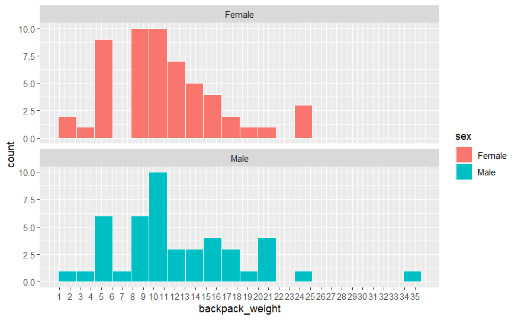

In this chart we can see the distribution of each weight depending on sex.

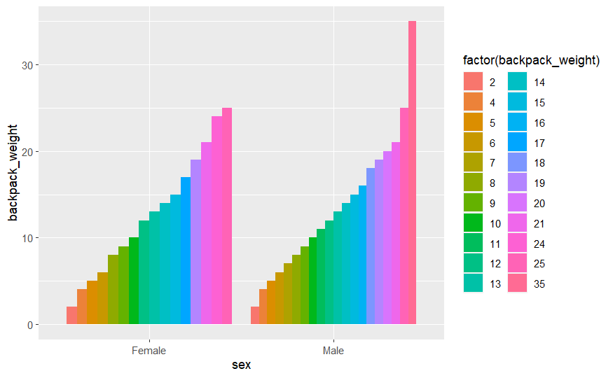

## Question 4.

What is the relationship between body weight and backpack weight?

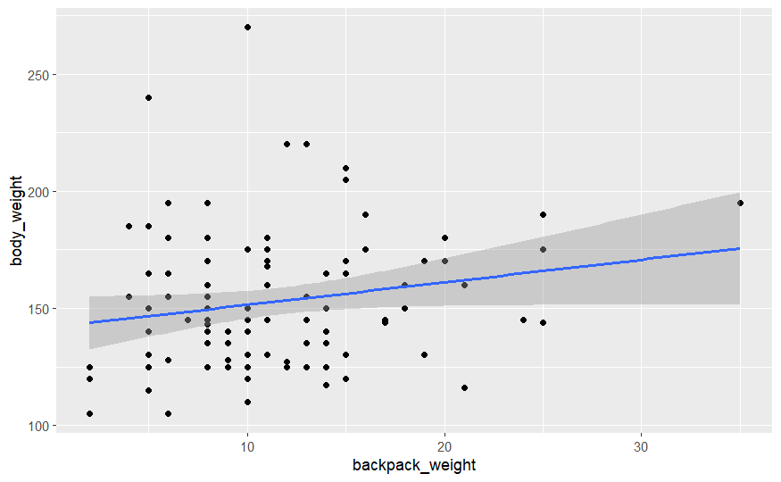

This chart gives me a general overview of the relation between backpack weights and body weights.

## Question 5.

Is this relationship different between men and women? Choose an appropriate plot and interpret your findings.

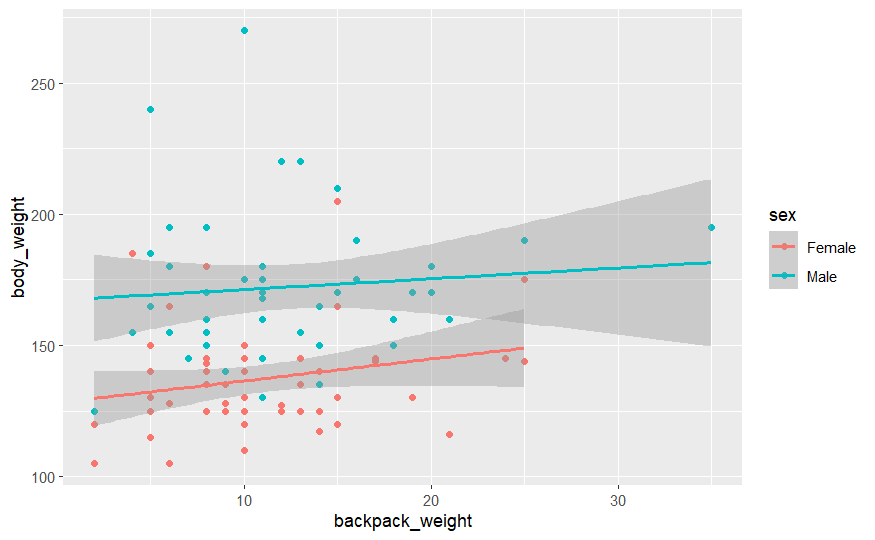

The trend of the relationship is more or less the same between men and women. However, of course, women has in general a weight trend line lower with respect to men.

## Question 6.

What proportion of students report back pain?

```r
backpack <- backpack %>%
  mutate(backpain_labelled = recode(back_problems,
                       "0" = "No",
                       "1" = "Yes"))
```

[output not shown]

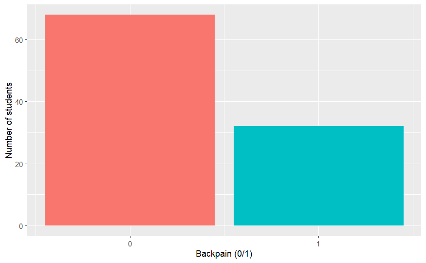

```r
backpack %>%
  ggplot() +
  aes(x = back_problems, fill = factor(back_problems)) +
  geom_bar()+
  scale_x_continuous(breaks = 0:1) +
  theme(legend.position = "none") +
  labs(x = "Backpain (0/1)",
       y = "Number of students",
       )
```

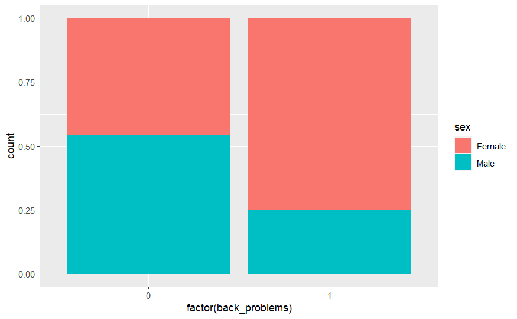

```r
backpack %>%
  ggplot(aes(x = factor(back_problems), fill = sex)) +
  geom_bar(position = "fill")
```

[figure not shown]

```r
backpack %>%
  ggplot(aes(x = "", fill = back_problems)) +
  geom_bar(position = "fill") +
  theme_minimal() +
  labs(y = "proportion",
       x = "proportion of students with back pain") +
  scale_y_continuous(labels = scales::percent)
```

This chart gives us the count of students who has back problems and the count of students who doesn’t.

## Question 7.

Is this proportion different between men and women?

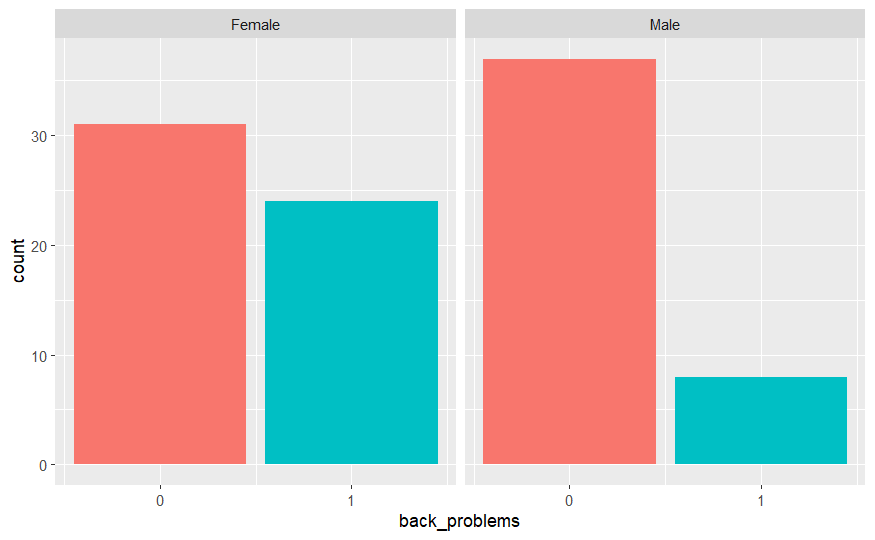

```r
backpack %>%
  ggplot() +
  aes(x = back_problems, fill = factor(back_problems)) +
  geom_bar()+
  scale_x_continuous(breaks = 0:1) +
  facet_wrap(~sex) +
  theme(legend.position = "none")
```

This chart compare the number of students with back problems with the number of students without back problems for both the two sexes.

## Question 8.

Now you’ve investigated your data separately, create plots to describe the relationship between backpack weight, body weight, gender and reported backpain.

Try both backpack_weight and body_weight as well as the ratio.

Hint: faceting would be useful here.

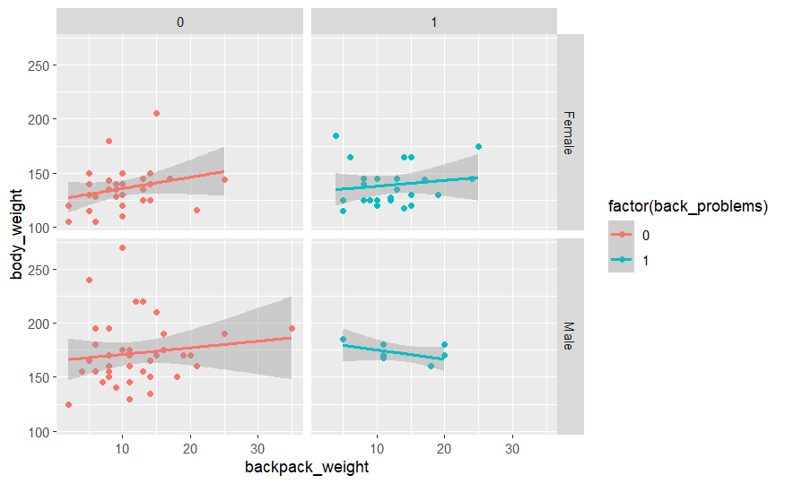

Here we show the relationship between backpack weight and body weight depending on gender and on back problems.

#Correction

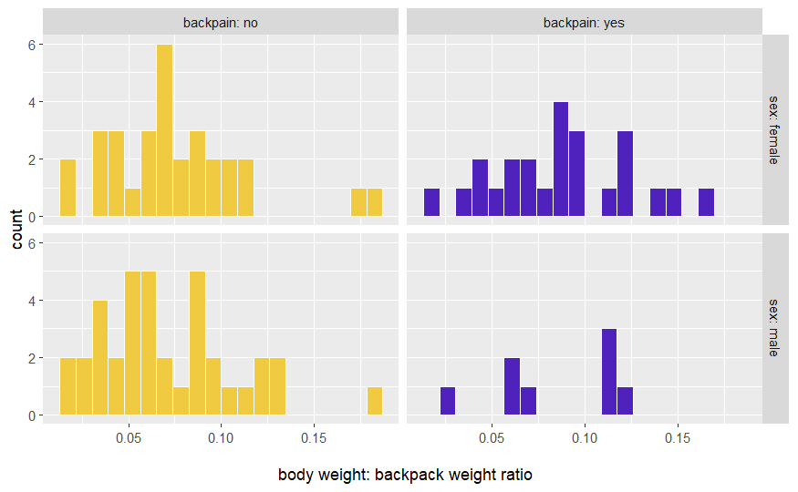